# Assignment1: CancerMortality

### Variable *pctprivatecoveragealone*

Numerical variable that represents the percentage of county residents with private health coverage alone (no public assistance at all).

The number of NA is humongous (356), but it has a small amount of mild outliers (4) and almost no skewness at all. Both using inferential and visualizations methods we cannot easily reject the hypothesis that this variable is not normal. So we can loosely say that is **normally** distributed.

```r
summary_and_normality_check(na.omit(train$pctprivatecoveragealone))
```

```
## [1] "Summary: "
##    Min. 1st Qu.  Median    Mean 3rd Qu.    Max.
##   16.80   41.50   49.00   48.65   55.50   78.90
## [1] "Mean"
## [1] 48.64807
## [1] "Standard deviation"
## [1] 10.06977
```

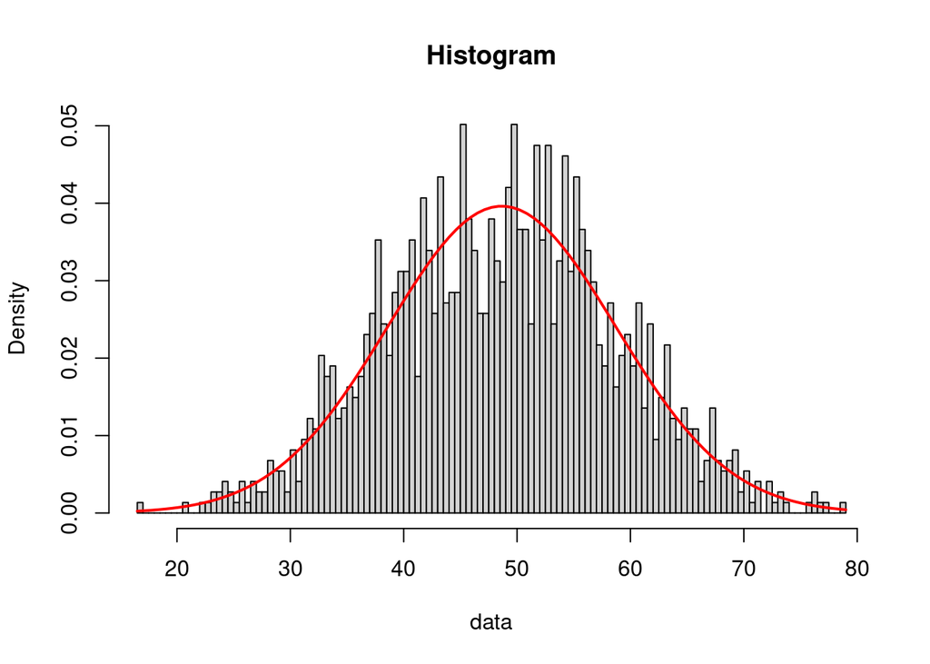

```
## [1] "Skewness"
## [1] 0.01553065
## [1] "Outliers: "
## $num_outliers
## [1] 4
##
## $num_severe_outliers
## [1] 0
##
## [1] "Shapiro test: "
##
##  Shapiro-Wilk normality test
##
## data:  data
## W = 0.99831, p-value = 0.1453
```

### Variable *pctempprivcoverage*

Numerical variable that represents the percentage of county residents with employee-provided private health coverage.

```r
summary_and_normality_check(na.omit(train$pctempprivcoverage))
```

```
## [1] "Summary: "
##    Min. 1st Qu.  Median    Mean 3rd Qu.    Max.
##   14.30   34.60   41.10   41.29   47.70   70.20
## [1] "Mean"
## [1] 41.29388
## [1] "Standard deviation"
## [1] 9.528869
```

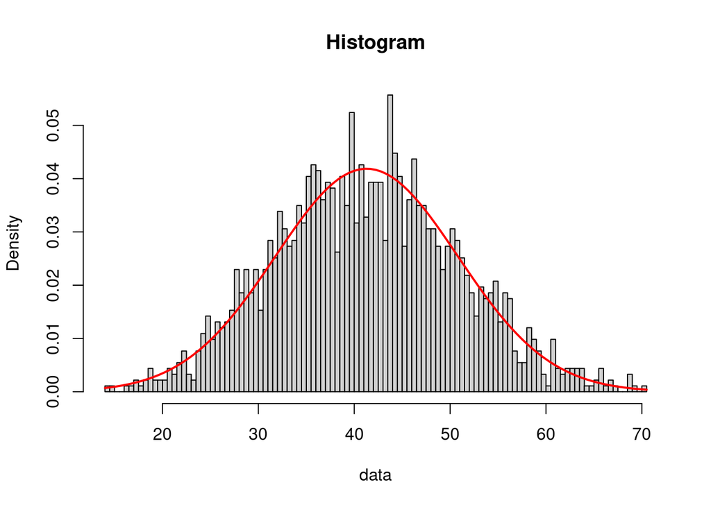

```
## [1] "Skewness"
## [1] 0.1082829
## [1] "Outliers: "
## $num_outliers
## [1] 7
##
## $num_severe_outliers
## [1] 0
##
## [1] "Shapiro test: "
##
##  Shapiro-Wilk normality test
##
## data:  data
## W = 0.99807, p-value = 0.02861
```